# GETurbine

This is the solution for the first question • It is recommended to first analyze the performance of turbine 190 compared to neighboring turbine 189. Consider the error if turbine 189 is used as an estimator of turbine 190. How well does this estimator perform?

**Read the data first**

```r
filenameToRead<-"train.csv"
turbineTrainData<-read.csv(filenameToRead)
str(turbineTrainData)
```

```
## 'data.frame':    999 obs. of  19 variables:
##  $ X180: num  998 972 787 477 373 ...
##  $ X181: num  963 525 325 188 191 ...
##  $ X183: num  1210 541 229 296 255 ...
##  $ X184: num  1396 837 612 957 815 ...
##  $ X185: num  380 560 836 794 737 ...
##  $ X186: num  280 524 854 677 664 ...
##  $ X187: num  309 575 896 677 694 ...
##  $ X188: num  309 470 902 591 608 ...
##  $ X189: num  400 525 950 652 677 ...
##  $ X190: num  732 953 964 836 713 ...
##  $ X191: num  758 383 447 289 236 ...
##  $ X193: num  964 834 927 796 658 ...
##  $ X194: num  315 463 1186 524 431 ...
##  $ X195: num  652 432 821 359 292 ...
##  $ X196: num  758 423 677 360 342 ...
##  $ X197: num  697 395 531 293 300 ...
##  $ X198: num  714 419 303 320 328 ...
##  $ X199: num  721 408 272 314 375 ...
##  $ X200: num  770 613 859 592 557 ...
```

**Performing some data explorations**

```r
#Find the summary of the values

summary(turbineTrainData$X189)
```

```
##    Min. 1st Qu.  Median    Mean 3rd Qu.    Max.
##  -12.45  271.20  559.60  659.60  960.50 1522.00
```

```r
summary(turbineTrainData$X190)
```

```
##     Min.  1st Qu.   Median     Mean  3rd Qu.     Max.
##    7.477  270.000  545.800  643.300  949.600 1522.000
```

The summary clearly shows that the X190 and X189 have similar distribution

Now drawing the box plts and the histograms to see the disribution

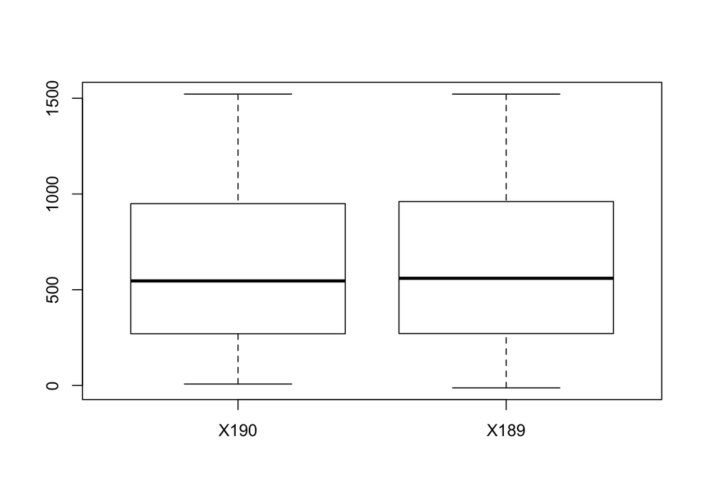

```r
#boxplots
boxplot(turbineTrainData$X190,turbineTrainData$X189,names=c("X190","X189"))
```

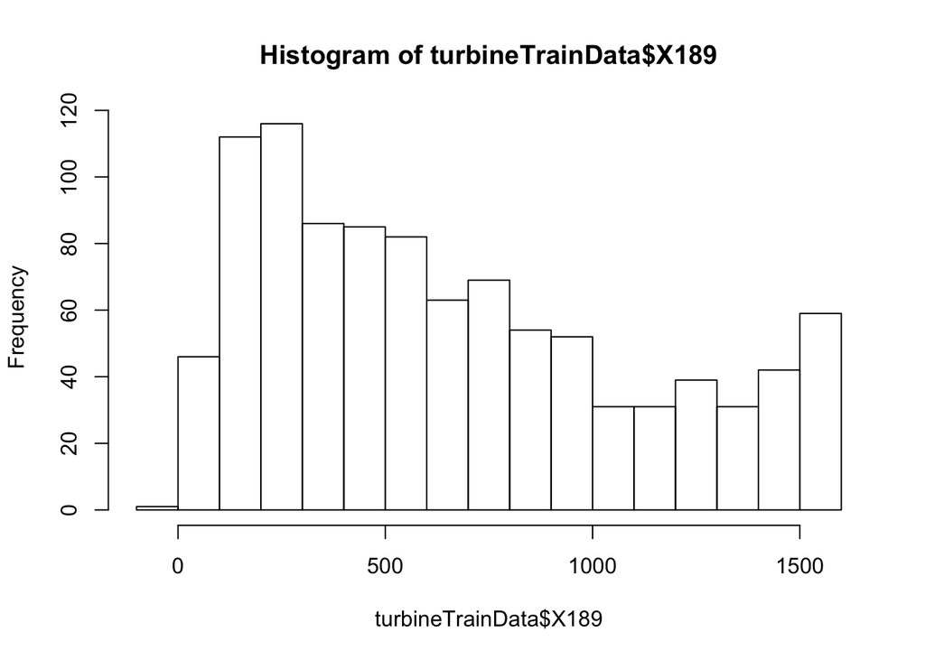

```r
#hist
hist(turbineTrainData$X189)
```

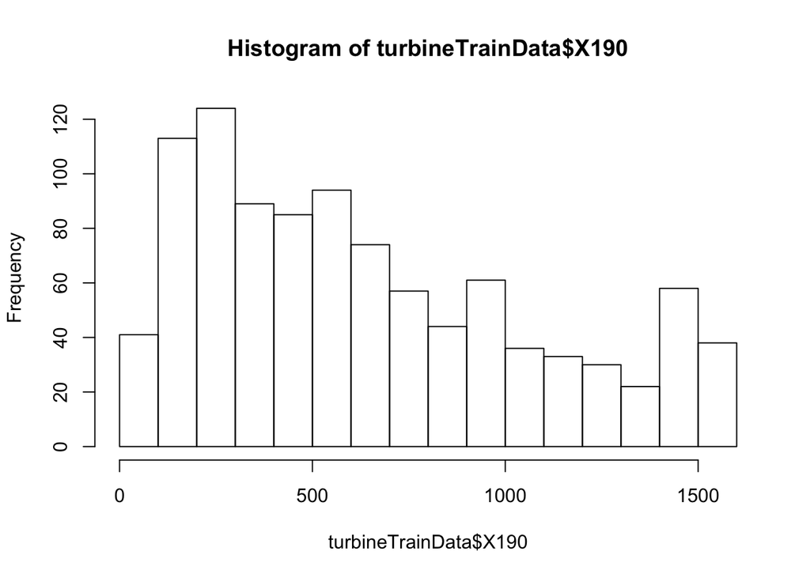

```r
hist(turbineTrainData$X190)
```

```r
#correlations
cor(turbineTrainData$X189,turbineTrainData$X190)
```

```
## [1] 0.9520749
```

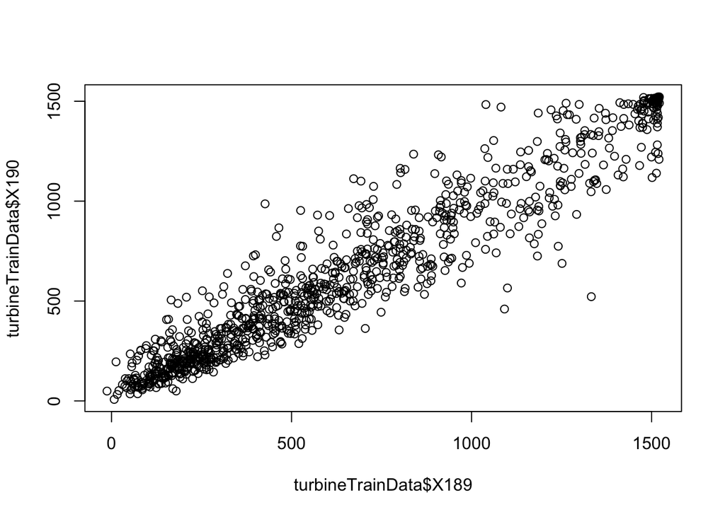

```r
#plot the points with the linear regression line
plot(turbineTrainData$X189,turbineTrainData$X190)
```

```r
#abline(lm(turbineTrainData$X190~turbineTrainData$X189), col="red")
```

So the above graphs indicate that there is strong relation between the two set of data points and it is possible to fit a line that passes through the bulk of points  
Also the histograms show that the distribution of 189 and 190 is similar and not Normal distribution

**Now fitting the model**

```r
linreg1=lm(X190~X189,data=turbineTrainData)
summary(linreg1)
```

```
##
## Call:
## lm(formula = X190 ~ X189, data = turbineTrainData)
##
## Residuals:
##     Min      1Q  Median      3Q     Max
## -742.01  -75.41   -6.22   69.72  558.14
##
## Coefficients:
##              Estimate Std. Error t value Pr(>|t|)
## (Intercept) 35.001737   7.456947   4.694 3.06e-06 ***
## X189         0.922244   0.009383  98.285  < 2e-16 ***
## ---
## Signif. codes:  0 '***' 0.001 '**' 0.01 '*' 0.05 '.' 0.1 ' ' 1
##
## Residual standard error: 131.5 on 997 degrees of freedom
## Multiple R-squared:  0.9064, Adjusted R-squared:  0.9064
## F-statistic:  9660 on 1 and 997 DF,  p-value: < 2.2e-16
```

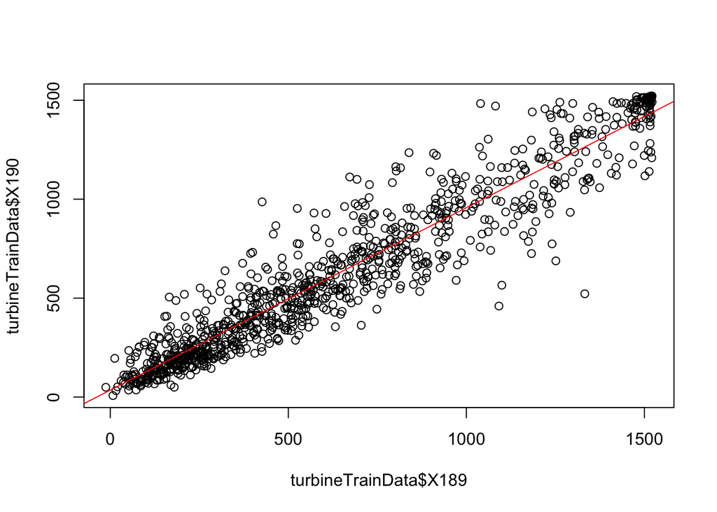

```r
#plot the points with the linear regression line
plot(turbineTrainData$X189,turbineTrainData$X190)
abline(lm(turbineTrainData$X190~turbineTrainData$X189), col="red")
```

```r
fittingTrain=predict(linreg1)

#getting the residuals values using the summary function
residualsBySummary=linreg1$residuals

#calculating the residuals using the predictions and the actual value in teh training data
residualTrain=turbineTrainData$X190-fittingTrain

#both should be same
diff=residualTrain-residualsBySummary

#calculate the SSE
trainSSE=sum(linreg1$residuals^2)
trainRMSE=sqrt(trainSSE/nrow(turbineTrainData))
trainRMSE
```

```
## [1] 131.3256
```

```r
trainSST=sum((turbineTrainData$X190-mean(turbineTrainData$X190))^2)
trainR2=1-trainSSE/trainSST
trainR2
```

```
## [1] 0.9064466
```

**Draw the standard error lines**

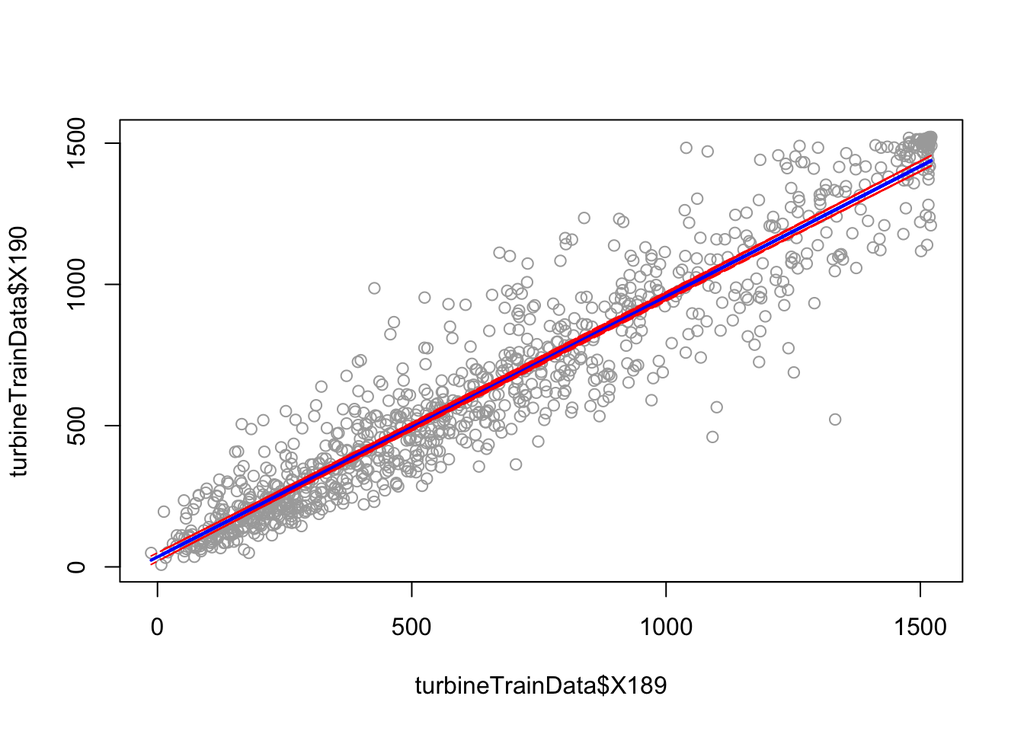

```r
par(mfrow=c(1,1))
preds<-predict(linreg1,se=TRUE)
#get the standard errors at any xo for the curve
se.bands=cbind(preds$fit+2*preds$se.fit,preds$fit-2*preds$se.fit)

#now plot the main region
plot(turbineTrainData$X189,turbineTrainData$X190,col="darkgrey")
#this is the main line
lines(turbineTrainData$X189,preds$fit,lwd=2,col="blue")
#now draw the SE lines
matlines(turbineTrainData$X189,se.bands,col="red",lty=2)
```

**Performing some linear regression diagnostics on the above model**

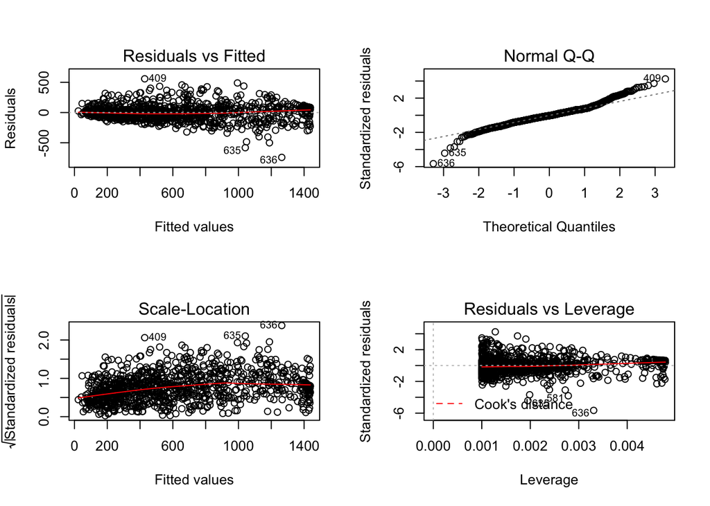

```r
par(mfrow=c(2,2))
#diagnostics
plot(linreg1)
```

```r
par(mfrow=c(1,1))
#plotting the outliers
plot(fitted.values(linreg1),rstudent(linreg1))
abline(h=c(-3,3), col="red")
which(rstudent(linreg1)>3)
```

```
##   2 409 587 617 919 920 922 985
##   2 409 587 617 919 920 922 985
```

```r
#another way to get the outliers
library(car)
```

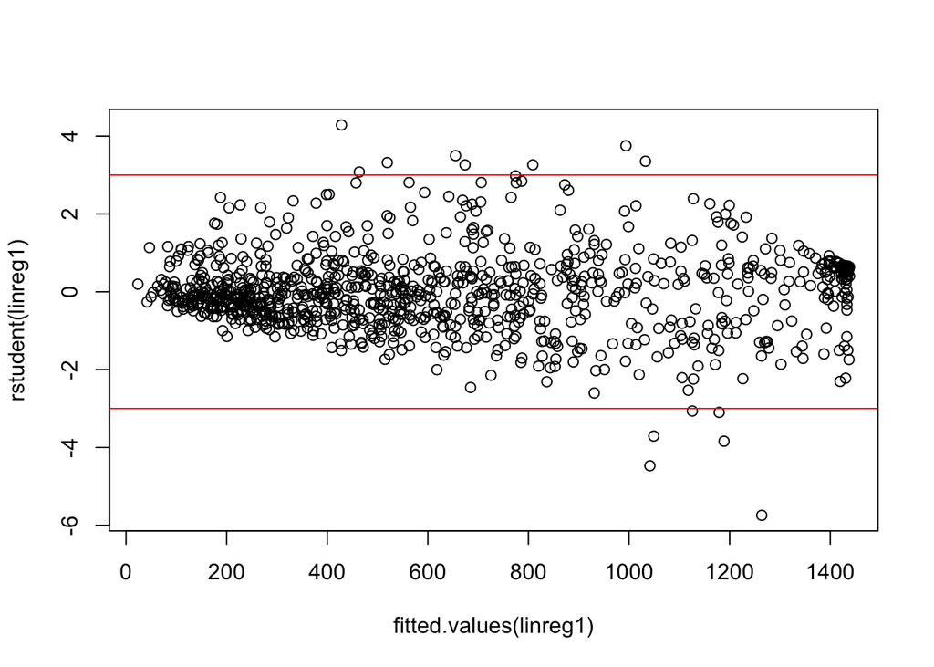

```r
outliers=outlierTest(linreg1)
outliers
```

```
##      rstudent unadjusted p-value Bonferonni p
## 636 -5.743882         1.2285e-08   1.2273e-05
## 635 -4.470386         8.7042e-06   8.6955e-03
## 409  4.285350         2.0015e-05   1.9995e-02
```

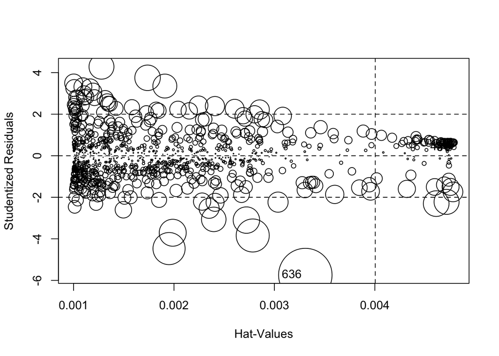

```r
#get the high lebvergare points
highLevPoints<-influencePlot(linreg1)
```

```r
highLevPoints
```

```
##        StudRes         Hat      CookD
## 447  0.4037525 0.004786744 0.01980819
## 636 -5.7438822 0.003307798 0.23031438
```

**Some obeservations**  
* We dont see many outliers or high leverage points * The plot between the residuals and fitted values is almost linear which indicates that the linear regression model is a good fit

Suppose we try to use a polynomial degree of the X189 just to see if that improves the R2 significantly

```r
polyLin<-lm(X190~poly(X189,3),data=turbineTrainData)
summary(polyLin)
```

```
##
## Call:
## lm(formula = X190 ~ poly(X189, 3), data = turbineTrainData)
##
## Residuals:
##     Min      1Q  Median      3Q     Max
## -739.04  -76.68   -4.90   62.33  553.72
##
## Coefficients:
##                 Estimate Std. Error t value Pr(>|t|)
## (Intercept)      643.322      4.152 154.937   <2e-16 ***
## poly(X189, 3)1 12920.323    131.237  98.450   <2e-16 ***
## poly(X189, 3)2   201.869    131.237   1.538   0.1243
## poly(X189, 3)3   226.473    131.237   1.726   0.0847 .
## ---
## Signif. codes:  0 '***' 0.001 '**' 0.01 '*' 0.05 '.' 0.1 ' ' 1
##
## Residual standard error: 131.2 on 995 degrees of freedom
## Multiple R-squared:  0.9069, Adjusted R-squared:  0.9067
## F-statistic:  3233 on 3 and 995 DF,  p-value: < 2.2e-16
```

The summary shows that the power of 1 is only significant and other powers are not that significant. So we dont require a model which has nonlinear relationship with predictor variables.

Run the model on the test data to see the predictions

```r
#read the test data
turbineTestData<-read.csv("test.csv")
summary(turbineTestData)
```

```
##       X180              X181              X183              X184
##  Min.   :   8.92   Min.   :   5.87   Min.   :  -7.41   Min.   :  -0.02
##  1st Qu.: 492.00   1st Qu.: 478.54   1st Qu.: 462.84   1st Qu.: 447.63
##  Median : 994.10   Median :1019.41   Median :1000.19   Median : 952.13
##  Mean   : 950.38   Mean   : 960.11   Mean   : 946.56   Mean   : 925.91
##  3rd Qu.:1476.44   3rd Qu.:1470.07   3rd Qu.:1460.80   3rd Qu.:1461.87
##  Max.   :1621.53   Max.   :1621.48   Max.   :1620.70   Max.   :1621.27
##       X185              X186              X187              X188
##  Min.   :   4.83   Min.   :   6.01   Min.   :   4.63   Min.   :   0.65
##  1st Qu.: 389.67   1st Qu.: 390.93   1st Qu.: 390.86   1st Qu.: 405.03
##  Median : 908.09   Median : 848.13   Median : 819.75   Median : 838.05
##  Mean   : 893.60   Mean   : 874.34   Mean   : 857.46   Mean   : 860.91
##  3rd Qu.:1415.82   3rd Qu.:1402.21   3rd Qu.:1370.47   3rd Qu.:1355.89
##  Max.   :1621.65   Max.   :1620.92   Max.   :1621.77   Max.   :1621.26
##       X189              X190              X191              X193
##  Min.   :  13.67   Min.   :  -1.57   Min.   :   8.95   Min.   :   8.69
##  1st Qu.: 384.87   1st Qu.: 371.59   1st Qu.: 393.87   1st Qu.: 411.94
##  Median : 841.64   Median : 869.80   Median : 867.47   Median : 878.31
##  Mean   : 873.42   Mean   : 865.89   Mean   : 881.34   Mean   : 882.98
##  3rd Qu.:1401.77   3rd Qu.:1384.94   3rd Qu.:1400.61   3rd Qu.:1394.25
##  Max.   :1620.61   Max.   :1620.72   Max.   :1620.72   Max.   :1621.47
##       X194              X195              X196              X197
##  Min.   :   5.21   Min.   :  26.05   Min.   :  -5.25   Min.   :  18.07
##  1st Qu.: 380.35   1st Qu.: 483.02   1st Qu.: 439.51   1st Qu.: 443.40
##  Median : 783.48   Median : 933.02   Median : 870.84   Median : 917.43
##  Mean   : 844.01   Mean   : 918.03   Mean   : 886.48   Mean   : 907.13
##  3rd Qu.:1352.73   3rd Qu.:1403.97   3rd Qu.:1389.19   3rd Qu.:1412.77
##  Max.   :1620.58   Max.   :1620.87   Max.   :1621.64   Max.   :1621.02
##       X198              X199              X200
##  Min.   :  13.04   Min.   :  17.41   Min.   :   9.1
##  1st Qu.: 442.90   1st Qu.: 477.63   1st Qu.: 484.1
##  Median : 898.94   Median : 928.78   Median : 980.9
##  Mean   : 906.81   Mean   : 929.25   Mean   : 934.5
##  3rd Qu.:1434.16   3rd Qu.:1442.40   3rd Qu.:1448.3
##  Max.   :1620.67   Max.   :1620.71   Max.   :1620.7
```

```r
turbineSubTestData=turbineTestData[c(1:2),]
predictionData=predict(linreg1,newdata=turbineTestData,interval="prediction")
predictions<-predictionData[1:nrow(predictionData)]
#coeffs<-coef(linreg1)
#predictions<-coeffs[1]+coeffs[2]*turbineTestData$X189
head(predictions)
```

```
## [1] 1393.938 1380.676 1427.904 1431.695 1429.029 1433.761
```

```r
str(turbineTestData)
```

```
## 'data.frame':    1501 obs. of  19 variables:
##  $ X180: num  1520 1521 1521 1521 1522 ...
##  $ X181: num  1503 1519 1522 1523 1519 ...
##  $ X183: num  1523 1523 1523 1522 1523 ...
##  $ X184: num  1516 1508 1519 1525 1521 ...
##  $ X185: num  1427 1500 1515 1509 1515 ...
##  $ X186: num  1524 1517 1505 1520 1509 ...
##  $ X187: num  1501 1489 1508 1463 1453 ...
##  $ X188: num  986 1372 1324 1518 1446 ...
##  $ X189: num  1474 1459 1510 1514 1512 ...
##  $ X190: num  1509 1515 1495 1510 1494 ...
##  $ X191: num  1372 1473 1482 1511 1499 ...
##  $ X193: num  1382 1348 1416 1520 1518 ...
##  $ X194: num  1087 1484 1508 1522 1520 ...
##  $ X195: num  1507 1516 1516 1517 1518 ...
##  $ X196: num  1545 1530 1547 1549 1547 ...
##  $ X197: num  1518 1521 1521 1521 1521 ...
##  $ X198: num  1517 1517 1518 1516 1518 ...
##  $ X199: num  1521 1518 1519 1516 1515 ...
##  $ X200: num  1518 1519 1521 1519 1520 ...
```

```r
testErrorDiff=turbineTestData$X190-predictions

testSSE=sum(testErrorDiff^2)
testRMSE=sqrt(testSSE/nrow(turbineTestData))
testRMSE
```

```
## [1] 141.8988
```

```r
#mean to be calculated on the trainig set
testSST=sum((turbineTestData$X190-mean(turbineTestData$X190))^2)
testR2=1-testSSE/testSST
testR2
```

```
## [1] 0.9226546
```

we can see that test R2 is slightly improved than the training R2.

**see how the predcitions and actual data is plotted**

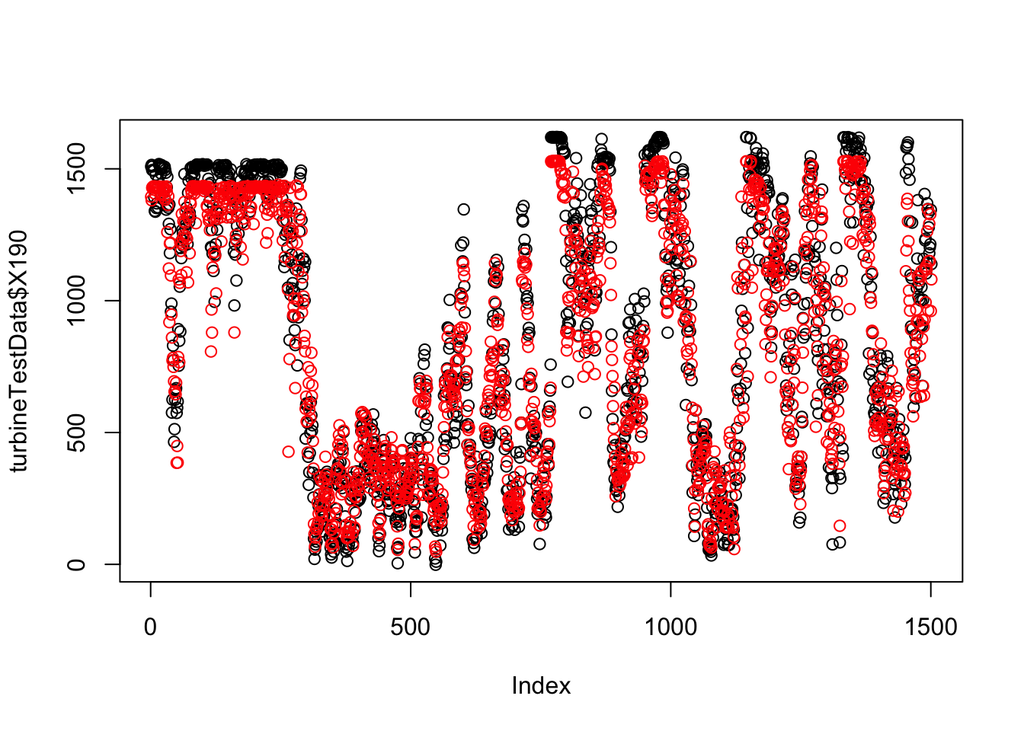

```r
plot(turbineTestData$X190)
points(predictions,col="red")
```